# Data Visualization 1

# 6 Presentation and Publication Plots

Many more examples can be found online, for example: http://www.cookbook-r.com/Graphs/

Here we are going to put together several of the ideas learned to make some plots that could be included in presentations or publications. We will go through these fairly briefly and they serve largely as a “cookbook” with some examples you may want to use yourself later.

Boxplot with raw data shown

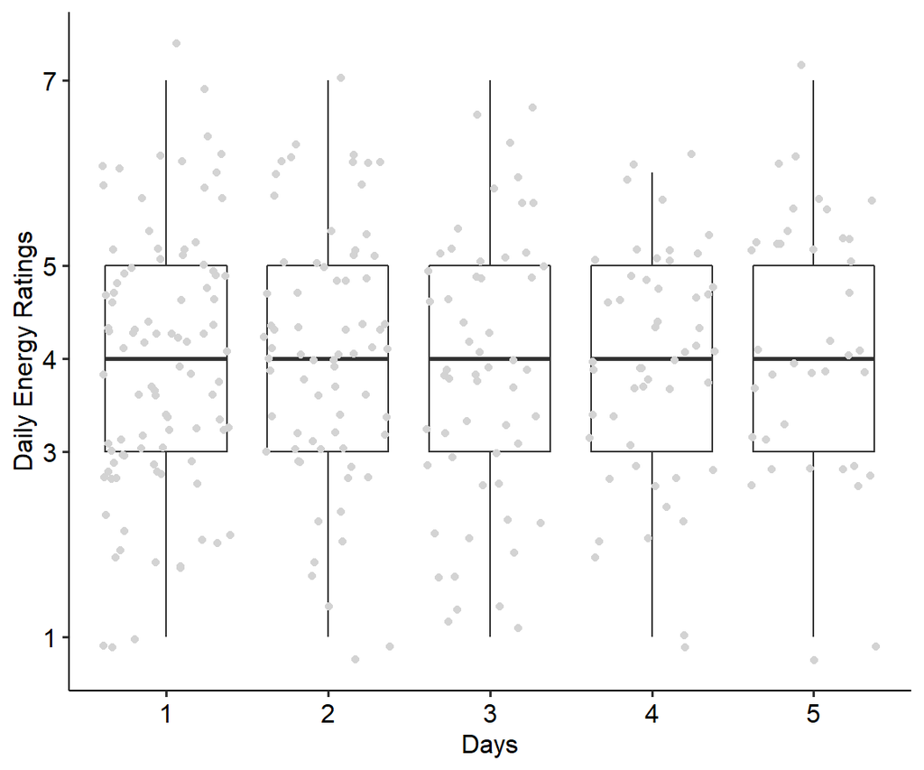

```r
ggplot(dd, aes(factor(SurveyDay), dEnergy)) +
  geom_boxplot() +
  geom_jitter(colour = "lightgrey") +
  theme_pubr() +
  scale_y_continuous(
    "Daily Energy Ratings",
    breaks = as.numeric(quantile(dd$dEnergy))) +
  xlab("Days")
```

Mean and 95 percent confidence interval

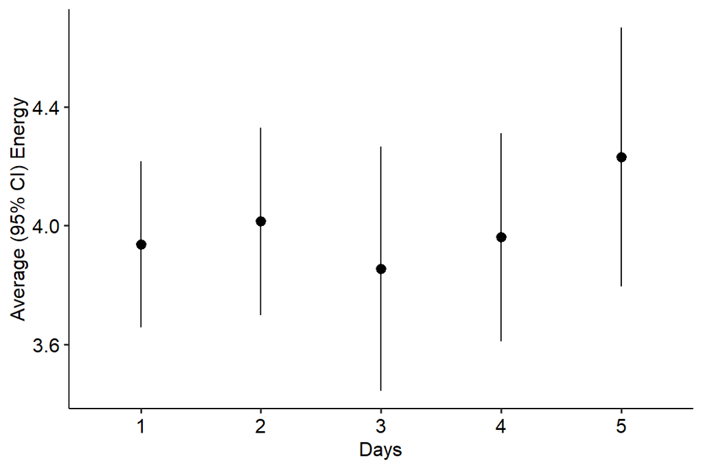

```r
ggplot(dd, aes(factor(SurveyDay), dEnergy)) +
  stat_summary(fun.data = mean_cl_normal) +
  theme_pubr() +
  ylab("Average (95% CI) Energy") +
  xlab("Days")
```

Chartjunk mean and 95 percent confidence interval

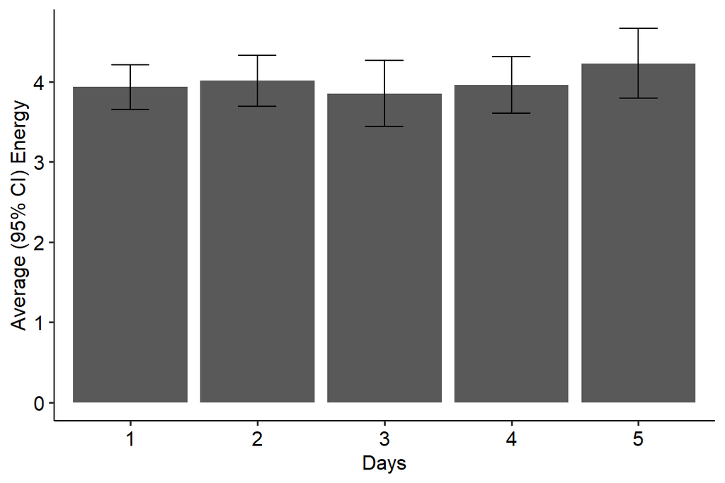

```r
ggplot(dd, aes(factor(SurveyDay), dEnergy)) +
  stat_summary(fun.data = mean_cl_normal, geom = "bar") +
  stat_summary(fun.data = mean_cl_normal, geom = "errorbar", width = .3) +
  theme_pubr() +
  ylab("Average (95% CI) Energy") +
  xlab("Days")
```

Mean and 95 percent confidence intervals

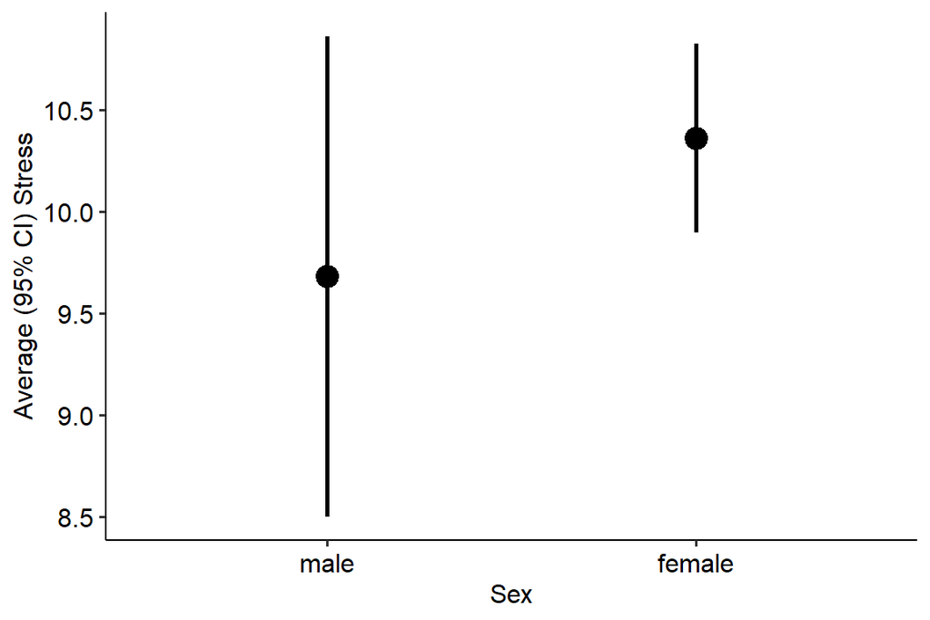

```r
ggplot(db[!is.na(sex)], aes(sex, Stress)) +
  stat_summary(fun.data = mean_cl_normal, size = 1) +
  theme_pubr() +
  ylab("Average (95% CI) Stress") +
  xlab("Sex")
```

Mean and 95 percent confidence interval with data

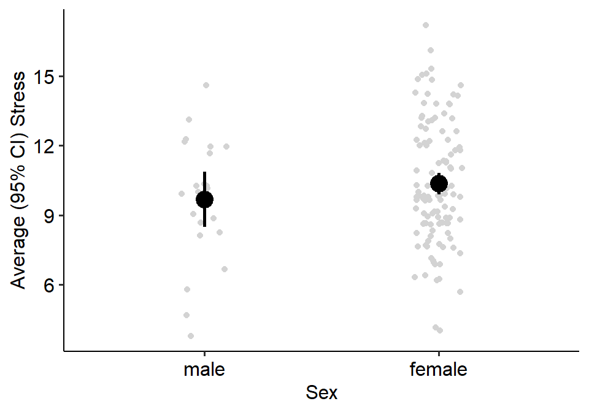

```r
ggplot(db[!is.na(sex)], aes(sex, Stress)) +
  geom_jitter(colour = "lightgrey", width = .1) +
  stat_summary(fun.data = mean_cl_normal, size = 1) +
  theme_pubr() +
  ylab("Average (95% CI) Stress") +
  xlab("Sex")
```

```r
## view the labels for one of the ULS items
attr(db$ULS1, "labels")
```

```
##     Never    Rarely Sometimes     Often
##         1         2         3         4
```

Likert plot of means showing anchors

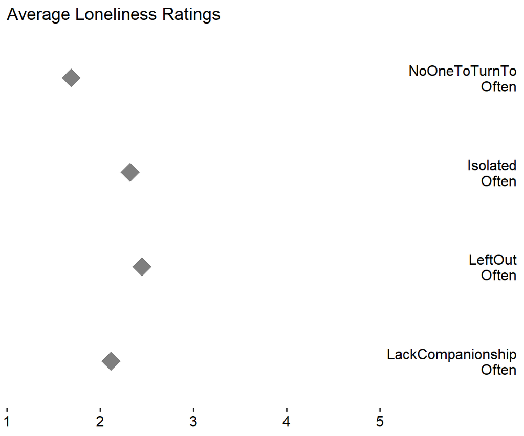

```r
## make a summarised dataset with the means and labels
sumdat <- melt(db[, .(ID,
            LackCompanionship = ULS1, LeftOut = ULS4,
            Isolated = ULS5, NoOneToTurnTo = ULS2)], id.vars = "ID")[,
  .(Mean = mean(value, na.rm = TRUE)), by = variable]
sumdat[, Never := paste0(variable, "\nNever")]
sumdat[, Often := paste0(variable, "\nOften")]

## make a likert plot
gglikert("Mean", "variable", "Never", "Often", data = sumdat,
         xlim = c(1, 5),
         title = "Average Loneliness Ratings")
```

# 7 Summary Table

Here is a little summary of some of the functions used in this topic. You might also enjoy this “cheatsheet” for `ggplot2`: https://github.com/rstudio/cheatsheets/raw/master/data-visualization-2.1.pdf

| Function | What it does |
| --- | --- |
| `ggplot()` | Sets the dataset and which variables map to which aesthetics for a plot |
| `geom_boxplot()` | Adds geometric object for boxplots |
| `geom_density()` | Adds a geometric object for density lines, a way to view a distribution |
| `geom_histogram()` | Adds a geometric object for a histogram, a way to view a distribution |
| `geom_jitter()` | Adds a points with some automatic random noise, helpful when one axis is discrete |
| `stat_summary()` | Used to automatically calculated some summary statistics on data and plot, usually means with standard errors or confidence intervals |
| `gglikert()` | Create a likert type plot showing means typically with the scale anchors |
| `plot(testDistribution())` | Used to check whether a variable follows a specific, assumed distribution, typically a normal distribution |
| `ylab()` | Adds a label for the y axis |
| `xlab()` | Adds a label for the x axis |